# 중간고사 대체 Report (201630314 김선화)

# ovarian data (난소암 환자들의 생존시간 데이터)

- **futime** : 생존시간
- **fustat** : censoring 여부
- **age** : 나이 (년)
- **resid.ds** : 잔존질환 발생 여부 (1-발생하지 않음, 2-발생)
- **rx** : 치료 방법

# 다음을 구하라

1. Kaplan-Meier plot + C.I.
2. rx에 따른 차이 확인
- Kaplan-Meier curves
- log-rank test
3. Cox model with 3 covariates 해석
4. Proportional hazards assumption 확인
- Graph
- Test

```r
library(survival)
attach(ovarian)
Y = Surv(futime, fustat)
```

# 1. Kaplan-Meier plot + C.I.

```r
KM = survfit(Y~1)
summary(KM)
```

```
## Call: survfit(formula = Y ~ 1)
##
##  time n.risk n.event survival std.err lower 95% CI upper 95% CI
##    59     26       1    0.962  0.0377        0.890        1.000
##   115     25       1    0.923  0.0523        0.826        1.000
##   156     24       1    0.885  0.0627        0.770        1.000
##   268     23       1    0.846  0.0708        0.718        0.997
##   329     22       1    0.808  0.0773        0.670        0.974
##   353     21       1    0.769  0.0826        0.623        0.949
##   365     20       1    0.731  0.0870        0.579        0.923
##   431     17       1    0.688  0.0919        0.529        0.894
##   464     15       1    0.642  0.0965        0.478        0.862
##   475     14       1    0.596  0.0999        0.429        0.828
##   563     12       1    0.546  0.1032        0.377        0.791
##   638     11       1    0.497  0.1051        0.328        0.752
```

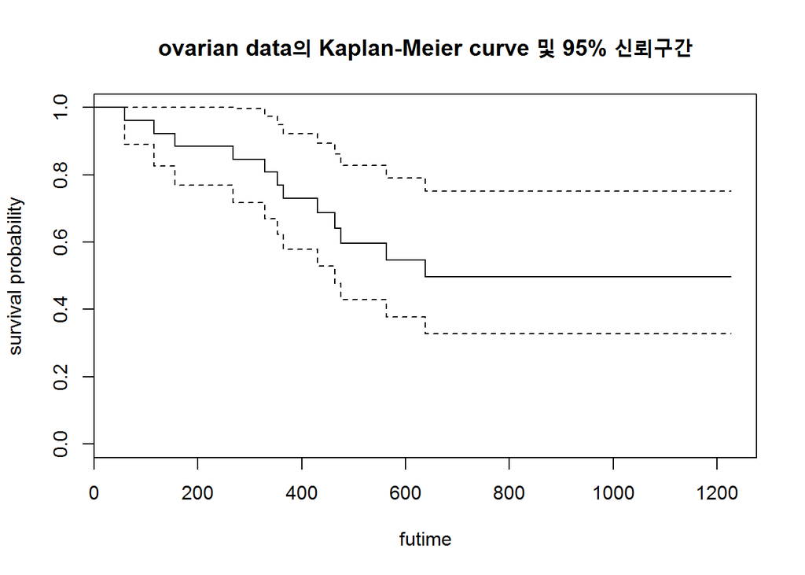

```r
plot(KM, main='ovarian data의 Kaplan-Meier curve 및 95% 신뢰구간', xlab='futime', ylab='survival probability')
```

실선은 ovarian data에 대한 Kaplan-Meier curve이고, 두 점선은 이 curve에 대한 95% 신뢰구간이다. 실선 아래에 있는 점선은 신뢰하한, 실선 위에 있는 점선은 신뢰상한이다. 위 `summary(KM)`을 통해서 각 futime별 생존확률에 대한 95% 신뢰구간을 확인할 수 있다.

# 2. rx에 따른 차이 확인

```r
KM1 = survfit(Y ~ rx)
summary(KM1)
```

```
## Call: survfit(formula = Y ~ rx)
##
##                 rx=1
##  time n.risk n.event survival std.err lower 95% CI upper 95% CI
##    59     13       1    0.923  0.0739        0.789        1.000
##   115     12       1    0.846  0.1001        0.671        1.000
##   156     11       1    0.769  0.1169        0.571        1.000
##   268     10       1    0.692  0.1280        0.482        0.995
##   329      9       1    0.615  0.1349        0.400        0.946
##   431      8       1    0.538  0.1383        0.326        0.891
##   638      5       1    0.431  0.1467        0.221        0.840
##
##                 rx=2
##  time n.risk n.event survival std.err lower 95% CI upper 95% CI
##   353     13       1    0.923  0.0739        0.789        1.000
##   365     12       1    0.846  0.1001        0.671        1.000
##   464      9       1    0.752  0.1256        0.542        1.000
##   475      8       1    0.658  0.1407        0.433        1.000
##   563      7       1    0.564  0.1488        0.336        0.946
```

#### **2-1. Kaplan-Meier curves를 이용하여 확인**

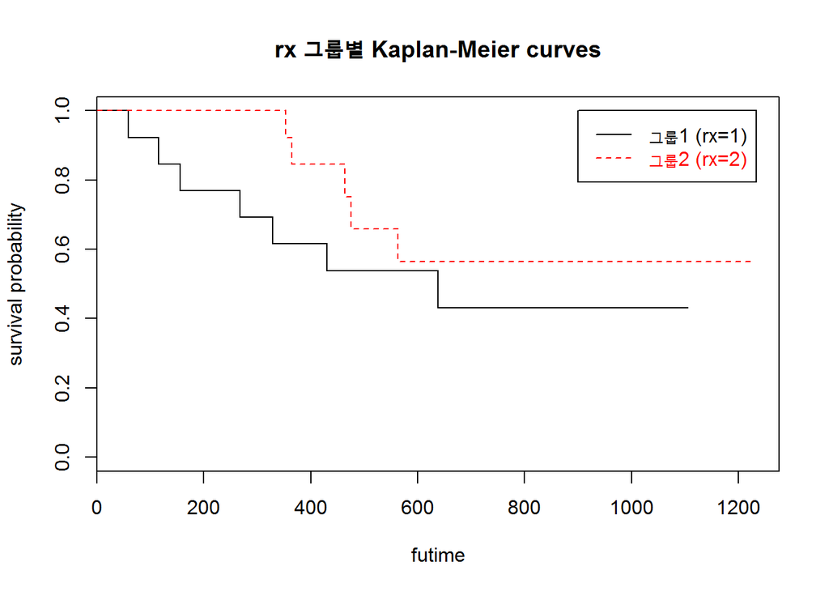

```r
plot(KM1, lty=c(1, 2), col=c(1, 2), main='rx 그룹별 Kaplan-Meier curves', xlab='futime', ylab='survival probability')
legend(900, 1, c('그룹1 (rx=1)', '그룹2 (rx=2)'), col=c(1, 2), lty=c(1, 2), text.col = c(1, 2))
```

검정선은 그룹1(rx=1)의 Kaplan-Meier curve, 빨간선은 그룹2(rx=2)의 Kaplan-Meier curve이다. futime이 500~600일 때까지 두 곡선 사이의 간격이 다소 넓다. 따라서 rx 그룹에 따라 두 Kaplan-Meier curve는 차이가 있어보인다.

#### **2-2. log-rank test를 이용하여 확인**

```r
survdiff(Y~rx)
```

```
## Call:
## survdiff(formula = Y ~ rx)
##
##       N Observed Expected (O-E)^2/E (O-E)^2/V
## rx=1 13        7     5.23     0.596      1.06
## rx=2 13        5     6.77     0.461      1.06
##
##  Chisq= 1.1  on 1 degrees of freedom, p= 0.303
```

$H_0$ : rx 그룹에 따른 두 Kaplan-Meier curve의 차이가 없다 vs $H_1$ : rx 그룹에 따른 두 Kaplan-Meier curve의 차이가 있다.  
결과에서 p=0.303 > 0.05이므로 귀무가설을 기각할 수 없다. 따라서 rx 그룹에 따른 두 Kaplan-Meier curve는 서로 다르다고 할 근거가 없다.

# 3. Cox model with 3 covariates 해석

#### **3-1. Proportional hazards model for 3 variables**

```r
ph = coxph(Y ~ age + resid.ds + rx)
summary(ph)
```

```
## Call:
## coxph(formula = Y ~ age + resid.ds + rx)
##
##   n= 26, number of events= 12
##
##             coef exp(coef) se(coef)      z Pr(>|z|)
## age       0.1285    1.1372   0.0473  2.718  0.00657 **
## resid.ds  0.6964    2.0065   0.7585  0.918  0.35858
## rx       -0.8489    0.4279   0.6392 -1.328  0.18416
## ---
## Signif. codes:  0 '***' 0.001 '**' 0.01 '*' 0.05 '.' 0.1 ' ' 1
##
##          exp(coef) exp(-coef) lower .95 upper .95
## age         1.1372     0.8794    1.0365     1.248
## resid.ds    2.0065     0.4984    0.4537     8.874
## rx          0.4279     2.3371    0.1222     1.498
##
## Concordance= 0.812  (se = 0.091 )
## Rsquare= 0.475   (max possible= 0.932 )
## Likelihood ratio test= 16.77  on 3 df,   p=0.0007889
## Wald test            = 14.63  on 3 df,   p=0.002164
## Score (logrank) test = 20.76  on 3 df,   p=0.0001182
```

1. 각 변수의 유의미 여부
- age의 p-value는 0.00657로 유의수준 0.05보다 작아 age 변수는 유의하다
- resid.ds의 p-value는 0.35858로 유의수준 0.05보다 크므로 resid.ds 변수는 유의하지 않다
- rx의 p-value는 0.18416로 유의수준 0.05보다 크므로 rx 변수는 유의하지 않다
2. 각 변수별 그룹의 위험 정도
- age가 1 단위 많아지면 exp(0.1285), 즉, 약 1.1배 더 위험해진다.
- 잔존질환이 발생한 그룹(resid.ds=2)이 발생하지 않은 그룹(resid.ds=1)보다 exp(0.6964), 즉, 약 2배 위험하다.
- 치료법1을 적용한 그룹(rx=1)이 치료법2를 적용한 그룹(rx=2)보다 exp(0.8489), 즉, 약 2.3배 위험하다.

#### **3-2. LRT (Likelihood Ratio Test)**

```r
ph1 = coxph(Y ~ age + resid.ds + rx + rx*resid.ds + rx*age + age*resid.ds)
anova(ph, ph1)
```

```
## Analysis of Deviance Table
##  Cox model: response is  Y
##  Model 1: ~ age + resid.ds + rx
##  Model 2: ~ age + resid.ds + rx + rx * resid.ds + rx * age + age * resid.ds
##    loglik  Chisq Df P(>|Chi|)
## 1 -26.601
## 2 -25.122 2.9574  3    0.3982
```

$H_0$ : 교호작용이 없다 vs $H_1$ : 교호작용이 있다  
귀무가설 가정하에서 likelihoo ratio 검정통계량은 2.9574 값이 나오고, 이것은 자유도가 3인 카이제곱분포를 따른다. 이 때의 p=0.3982 > 0.05이어서 귀무가설을 기각하지 못 한다. 교호작용이 없는 모델, 즉, “ph = coxph(Y ~ age + resid.ds + rx)”을 선택한다.

## 4. Proportional hazards assumption 확인

#### **4-1. Graph를 이용하여 확인**

##### 4-1-①. Proportional hazards assumption for resid.ds

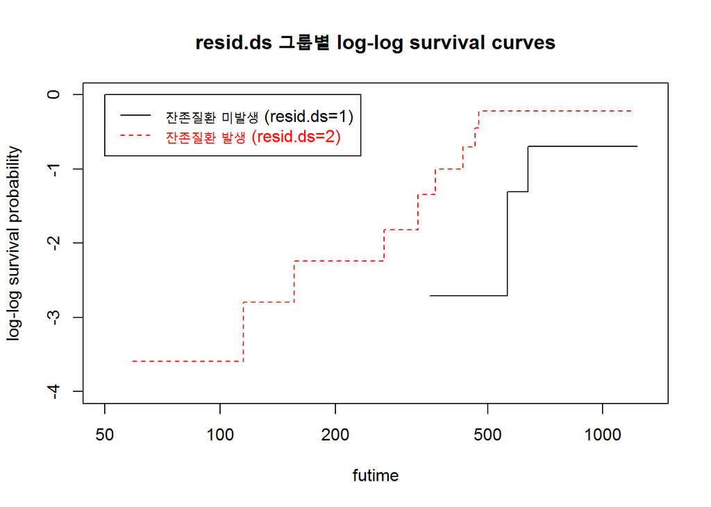

```r
new1 = data.frame(rx0 = mean(rx), age0 = mean(age))
I1 = (resid.ds == 1); I2 = (resid.ds == 2)
rx0 = rx[I1]; age0 = age[I1]
ph2_1 = coxph(Y[I1] ~ rx0 + age0)
plot(survfit(ph2_1, newdata = new1), conf.int=F, fun="cloglog", xlim=c(50, 1300), ylim=c(-4, 0), main='resid.ds 그룹별 log-log survival curves', xlab='futime', ylab='log-log survival probability')   # 잔존질환이 발생하지 않은 그룹의 log-log survival curve
rx0 = rx[I2]; age0 = age[I2]
ph2_2 = coxph(Y[I2] ~ rx0 + age0)
lines(survfit(ph2_2, newdata = new1), conf.int=F, fun="cloglog", col=2, lty = 2)   # 잔존질환이 발생한 그룹의 log-log survival curve
legend(50, 0, c('잔존질환 미발생 (resid.ds=1)', '잔존질환 발생 (resid.ds=2)'), col=c(1, 2), lty=c(1, 2), text.col = c(1, 2))
```

두 그룹의 log-log survival curve가 교차되는 지점이 없고 거의 평행한 것으로 보아 resid.ds 변수는 Proportional hazards 가정을 만족한다.

##### 4-1-②. Proportional hazards assumption for rx

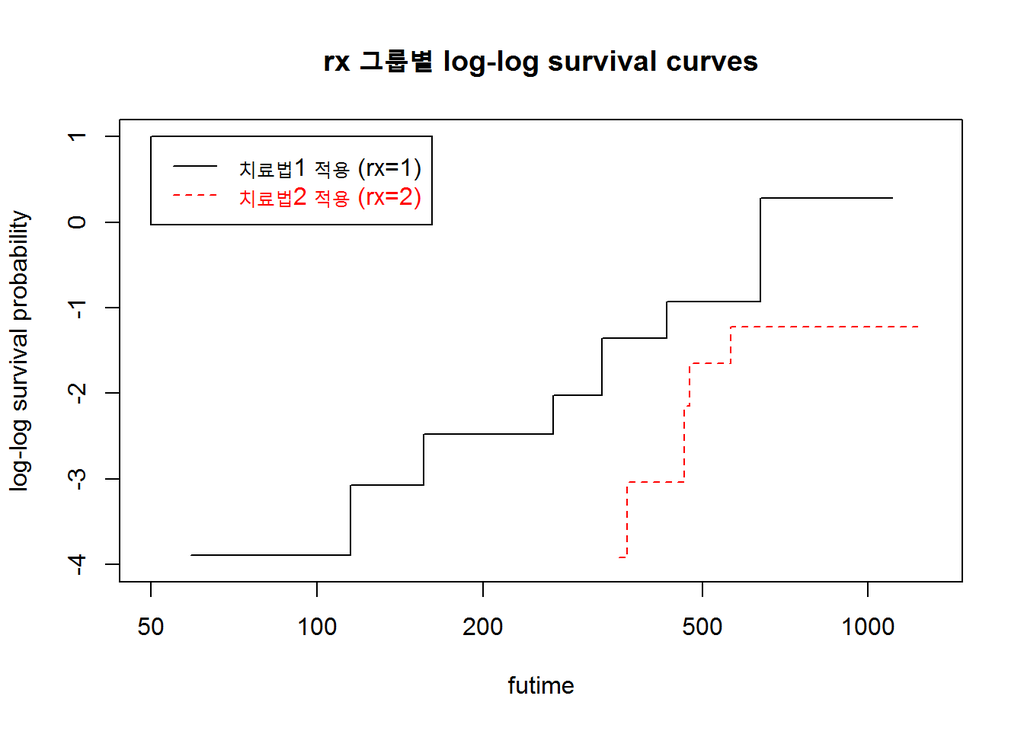

```r
new2 = data.frame(resid.ds0 = mean(resid.ds), age0 = mean(age))
I1 = (rx == 1); I2 = (rx == 2)
resid.ds0 = resid.ds[I1]; age0 = age[I1]
ph3_1 = coxph(Y[I1] ~ resid.ds0 + age0)
plot(survfit(ph3_1, newdata = new2), conf.int=F, fun="cloglog", xlim=c(50, 1300), ylim=c(-4, 1), main='rx 그룹별 log-log survival curves', xlab='futime', ylab='log-log survival probability')   # 치료법 1을 적용한 그룹(rx=1)의 log-log survival curve
resid.ds0 = resid.ds[I2]; age0 = age[I2]
ph3_2 = coxph(Y[I2] ~ resid.ds0 + age0)
lines(survfit(ph3_2, newdata = new2), conf.int=F, fun="cloglog", col=2, lty = 2)   # 치료법 2를 적용한 그룹(rx=2)의 log-log survival curve
legend(50, 1, c('치료법1 적용 (rx=1)', '치료법2 적용 (rx=2)'), col=c(1, 2), lty=c(1, 2), text.col = c(1, 2))
```

두 그룹의 log-log survival curve가 교차되는 지점이 없고 거의 평행한 것으로 보아 rx 변수는 Proportional hazards 가정을 만족한다.

##### 4-1-③. Proportional hazards assumption for age

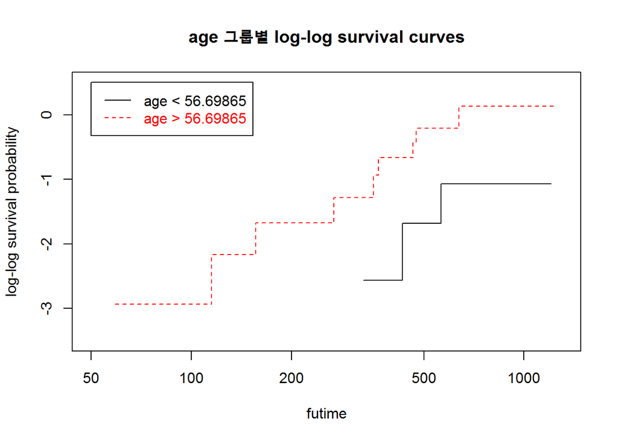

```r
new3 = data.frame(resid.ds0 = mean(resid.ds), rx0 = mean(rx))
I1 = (age < 56.69865); I2 = (age >= 56.69865)
rx0 = rx[I1]; resid.ds0 = resid.ds[I1]
ph4_1 = coxph(Y[I1] ~ rx0 + resid.ds0)
plot(survfit(ph4_1, newdata = new3), conf.int=F, fun="cloglog", xlim=c(50, 1300), ylim=c(-3.5, 0.5), main='age 그룹별 log-log survival curves', xlab='futime', ylab='log-log survival probability')   # age가 56.69865 미만인 그룹의 log-log survival curve
rx0 = rx[I2]; resid.ds0 = resid.ds[I2]
ph4_2 = coxph(Y[I2] ~ rx0 + resid.ds0)
lines(survfit(ph4_2, newdata = new3), conf.int=F, fun="cloglog", col=2, lty = 2)   # age가 56.69865 이상인 그룹의 log-log survival curve
legend(50, 0.5, c('age < 56.69865', 'age > 56.69865'), col=c(1, 2), lty=c(1, 2), text.col = c(1, 2))
```

두 그룹의 log-log survival curve가 교차되는 지점이 없고 거의 평행한 것으로 보아 age 변수는 Proportional hazards 가정을 만족한다.

#### **4-2. Proportional hazards assumption test를 이용하여 확인**

```r
cox.zph(ph, transform = rank)
```

```
##              rho   chisq     p
## age      -0.0115 0.00238 0.961
## resid.ds -0.2274 0.71534 0.398
## rx        0.2144 0.59376 0.441
## GLOBAL        NA 1.43222 0.698
```

$H_0$ : Proportional hazards 가정을 만족한다 vs $H_1$ : Proportional hazards 가정을 만족하지 않는다  
age, resid.ds, rx의 p-value가 유의수준 0.05보다 크므로 귀무가설을 기각할 수 없다. 따라서 Proportional hazards 가정을 만족하지 않는다는 충분한 근거가 없다.